# Covid-19 in Finland - Case Study

Emil Sievänen

1/29/2021

# Introduction

In this notebook, we visualize the coronavirus situation in Finland. We use a dataset acquired from the [Finnish Institute for Health and Welfare](https://thl.fi/fi/tilastot-ja-data/aineistot-ja-palvelut/avoin-data/varmistetut-koronatapaukset-suomessa-covid-19-) and use the `tidyverse` and `ggmap` packages to manipulate and visualize the data. The `ggmap` package uses the Google Maps API, so it is necessary to sign up to the Google Cloud Platform to be able to access the API. The full source code is available at the projects [GitHub repository](https://github.com/eenaveis/covid-19).

# Data Preparation

Lets get started by importing our data. The Google Cloud Platform API key is stored in our home directory in a “.Renviron” file, so you need to create that file as well, or directly copy and paste the API key as a string to the `api_key` variable in R.

```r
api_key <- Sys.getenv("GOOGLE_MAPS")
covid1 <- read_csv2("./data/covid19case.csv")
```

Lets take a look at our data.

```
## # A tibble: 2,332 x 3
##    Aika                 Alue         val
##    <chr>                <chr>      <dbl>
##  1 Vuosi 2020 Viikko 01 Ahvenanmaa     0
##  2 Vuosi 2020 Viikko 02 Ahvenanmaa     0
##  3 Vuosi 2020 Viikko 03 Ahvenanmaa     0
##  4 Vuosi 2020 Viikko 04 Ahvenanmaa     0
##  5 Vuosi 2020 Viikko 05 Ahvenanmaa     0
##  6 Vuosi 2020 Viikko 06 Ahvenanmaa     0
##  7 Vuosi 2020 Viikko 07 Ahvenanmaa     0
##  8 Vuosi 2020 Viikko 08 Ahvenanmaa     0
##  9 Vuosi 2020 Viikko 09 Ahvenanmaa     0
## 10 Vuosi 2020 Viikko 10 Ahvenanmaa     0
## # … with 2,322 more rows
```

It seems that our date column is formatted badly so we need to reformat it to a more structured representation. We first split the “Aika” column with `separate` (which is in finnish and means time) and then we combine the “year” and “week” columns into a one column named “date” and convert it to a date object. After that we rename the columns and drop all rows with missing values.

```r
covid2 <- covid1 %>%
  separate(Aika, c("y", "year", "w", "week"), sep =" ") %>%
  select(-y, -w) %>%
  unite(date, c(year, week), sep = "") %>%
  mutate(date = paste(date, "04", sep = "")) %>%
  transmute(date = as.Date(date, "%Y%U%w"), area = Alue, cases = val) %>%
  filter(!is.na(cases), !is.na(date))
```

# Exploratory Analysis

Now that we have our data cleaned, we start to examine our data more in depth. Lets start by summarising the data. The below output summarises the total covid-19 cases by different areas.

```
## # A tibble: 22 x 2
##    area                       total_cases
##    <chr>                            <dbl>
##  1 Kaikki Alueet                    37584
##  2 Helsingin ja Uudenmaan SHP       22034
##  3 Varsinais-Suomen SHP              3371
##  4 Pirkanmaan SHP                    2001
##  5 Pohjois-Pohjanmaan SHP            1658
##  6 Vaasan SHP                        1343
##  7 Keski-Suomen SHP                  1230
##  8 Päijät-Hämeen SHP                  993
##  9 Kanta-Hämeen SHP                   656
## 10 Kymenlaakson SHP                   592
## # … with 12 more rows
```

As we can see, the first area “Kaikki Alueet” (All Areas) counts the covid-19 cases in all of the areas. We will need to remove those values for the following steps we have. It also seems that the Helsinki area has clearly the most covid-19 cases in all of the areas. Lets plot the total covid-19 cases in the top 5 areas.

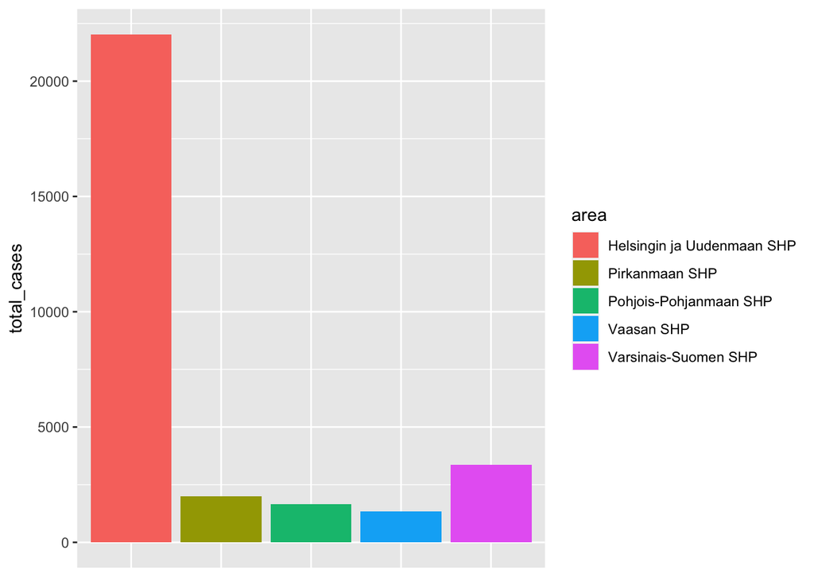

This plot confirms the notion that the Helsinki area has the most significant exposure to covid-19. Lets have a look how the covid-19 cases have developed with the passage of time.

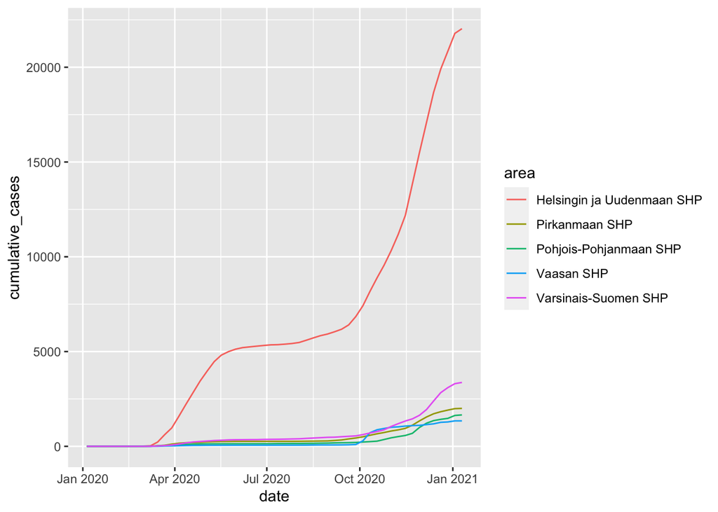

As we can see, the covid-19 cases have exploded after October 2020 in all of the areas, most notably in the Helsinki area. As a final step, lets put the covid-19 cases on a map to have a better view where exactly the covid-19 has spread. We use the `ggmap` package to draw the map, which is built on top of the `ggplot2` package. We have also built a new tibble that has additional columns representing the latitude and longitude coordinates of the different areas in the top 5 areas, so that we can plot the total cases on the map.

[figure not shown]

```r
# area coordinates
coordinates_HUS <- c(24.943536799, 60.166640739)
coordinates_PS <- c(23.761290078, 61.497742570)
coordinates_PPS <- c(25.472099070, 65.013784817)
coordinates_VS <- c(21.615874122, 63.092588875)
coordinates_VSS <- c(22.266866666, 60.451690351)
# center point coordinates (Jyväskylä)
coordinates_center <- c(lon = 25.72088, lat = 62.24147)

lon <- c(coordinates_HUS[1],
         coordinates_PS[1],
         coordinates_PPS[1],
         coordinates_VS[1],
         coordinates_VSS[1])

lat <- c(coordinates_HUS[2],
         coordinates_PS[2],
         coordinates_PPS[2],
         coordinates_VS[2],
         coordinates_VSS[2])

covid5  <- covid3 %>% add_column(lon, lat)

map <- ggmap(get_googlemap(coordinates_center, zoom = 6))
map +
  geom_point(aes(x = lon, y = lat, size = total_cases),
             data = covid5,
             color = "blue",
             alpha = 0.5
             ) +
  theme(axis.ticks = element_blank(),
        axis.title = element_blank(),
        axis.text = element_blank(),
        legend.position = "none") +
  scale_size_continuous(range = c(5, 30))
```

Now it is more clearly seen where the covid-19 has spread the most. This is it for this time, next time we will do some big data analysis with the IMDB data. In the meanwhile, be sure to check out my other [projects](https://github.com/eenaveis/) too!